# Speed-acc-adult Fit EWMA model

Kyle MacDonald

This script analyzes first shift accuracy and RT using an EWMA guesssing model. In the task, we vary the information value and the saliency of the center fixation and measure the effects on accuracy and RT.

## Setup

Load libraries and read in tidy data.

Clean the spoken English and sign language datasets, so we can merge them.

Merge the datasets.

### RT analysis

First, we analyze RT and accuracy of first shifts computed from noun onset.

| shift_type | response_onset_type | n | total_shifts | prop |
| --- | --- | --- | --- | --- |
| C_D | center.fixation | 281 | 1832 | 0.15 |
| C_D | noun | 196 | 2547 | 0.08 |
| C_D | sentence | 290 | 1952 | 0.15 |
| C_T | center.fixation | 1551 | 1832 | 0.85 |
| C_T | noun | 2351 | 2547 | 0.92 |
| C_T | sentence | 1662 | 1952 | 0.85 |

Regardless of when you start the clock, ~10% of shifts are incorrect. This makes sense since this is an easy task for adults.

Plot the distribution of RTs for correct vs. incorrect shifts from noun onset.

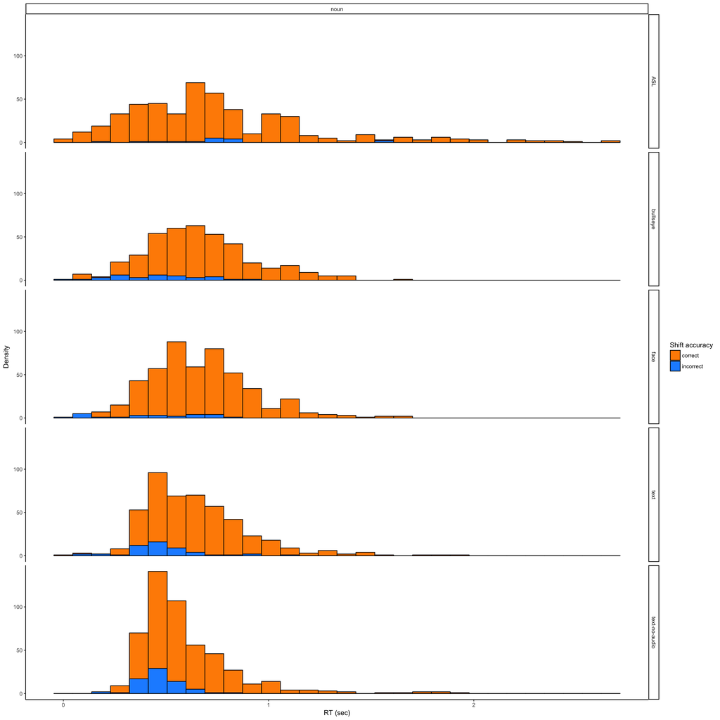

I’m not sure how we should handle shifts that happen before noun onset? My thought is to feed them into the EWMA, but not into the summary analyses and the DDM fits.

#### Plot RT by condition

First we aggregate median RT for each participant.

Then we make a boxplot.

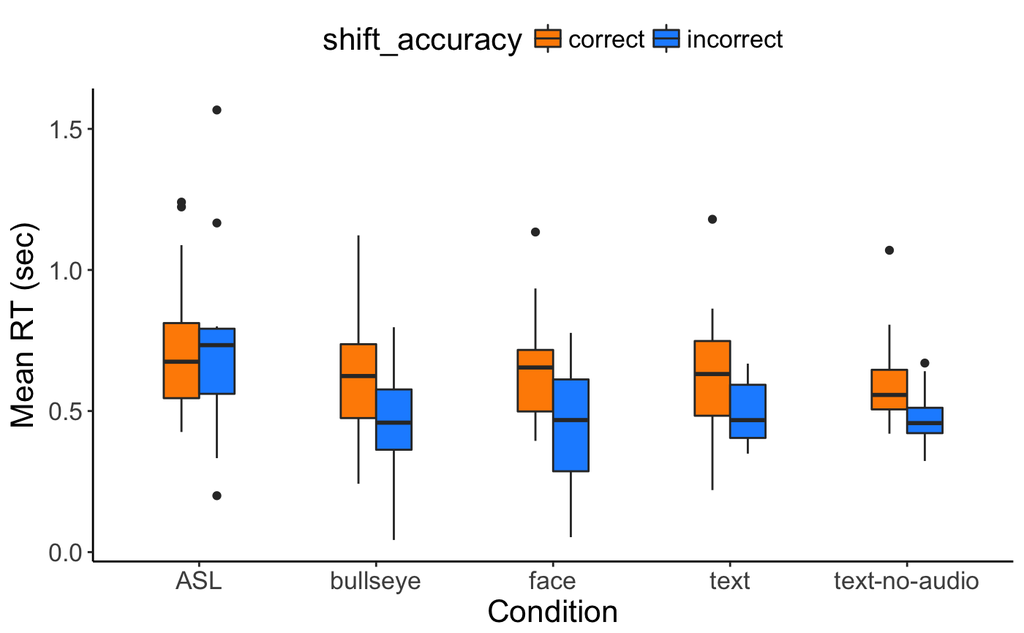

Get an estimate of the effect size for the RT difference between ASL and Face conditions.

```
Cohen's d

d estimate: 0.6746853 (medium)
95 percent confidence interval:
      inf       sup
0.1609674 1.1884031
```

### Accuracy

First we aggregate mean Accuracy for each participant.

Then we make a boxplot.

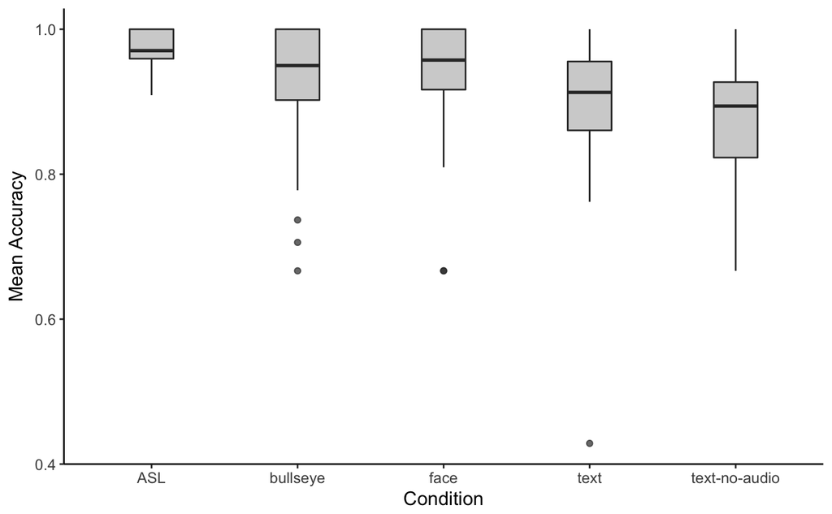

## EWMA filter to model guessing behavior

First we munge the data to feed into the EWMA function.

TODO: Simulate this model across different values of *L* and $\lambda$. *L* controls the width of the threshold. $\lambda$ controls the number of previous trials that go into the moving average computation.

```
|=====================================================================================|100% ~0 s remaining
```

Write EWMA results to .csv so we can use this information in the Drift Diffusion analysis.